# Raport z wykresami 2

Twoim celem jest odtworzenie tych wykresów, stworzonych przy użyciu danych Cooperative Congressional Election Study.

## Wykres 1

**Wskazówki:**

- Dla osi x użyj zmiennej “ideo5”.
- Upewnij się, że przekodujesz dane dla zmiennej “ideo5”, aby wygenerować poprawne nazwy dla osi x. Będziesz musiał zajrzeć do książki kodowej.
- Użyj estetyki `fill`, aby R wypełnił słupki. Nie musisz ustawiać kolorów ręcznie.
- Użyj `guides()` do usunięcia legendy.
- Upewnij się, że etykiety osi i tytuł wykresu są poprawne.

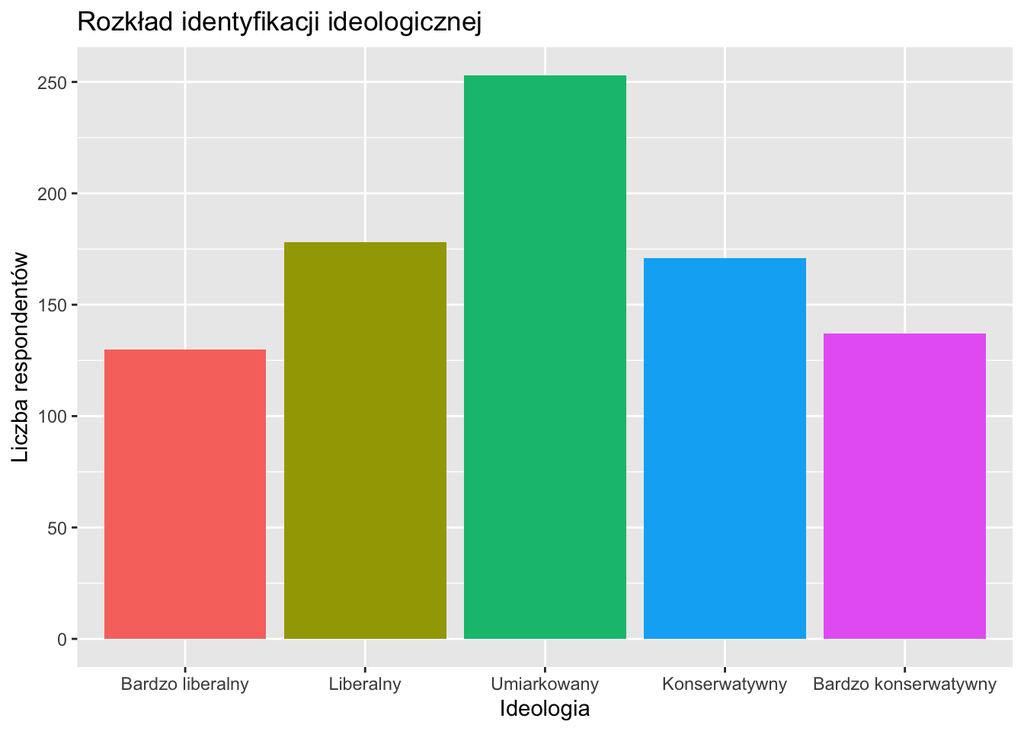

```r
####KOD
# Filtrujemy wartości 'Nie wiem' (6) i braki danych, a następnie przypisujemy etykiety
cces_plot1 <- cces %>%
  filter(ideo5 %in% 1:5) %>%
  mutate(ideo5 = factor(ideo5,
                        levels = 1:5,
                        labels = c("Bardzo liberalny", "Liberalny", "Umiarkowany",
                                   "Konserwatywny", "Bardzo konserwatywny")))

# Tworzymy wykres słupkowy.
# guides(fill = "none") usuwa legendę, bo kolory i tak odpowiadają osi x.
ggplot(cces_plot1, aes(x = ideo5, fill = ideo5)) +
  geom_bar() +
  guides(fill = "none") +
  labs(
    x = "Ideologia",
    y = "Liczba respondentów",
    title = "Rozkład identyfikacji ideologicznej"
  )
```

## Wykres 2

**Wskazówki:**

- Dla osi x użyj zmiennej “pew_religimp”.
- Upewnij się, że przekodujesz dane dla zmiennej “pew_religimp”, aby wygenerować poprawne etykiety dla osi x. Będziesz musiał zajrzeć do książki kodowej.
- Zmień nazwę kolumny dla Ideologii, aby pierwsza litera była wielka (aby legenda wyświetlała się poprawnie).
- Użyj estetyki `fill`, aby R wypełnił słupki. Nie musisz ustawiać kolorów ręcznie.
- Upewnij się, że etykiety osi i tytuł wykresu są poprawne.

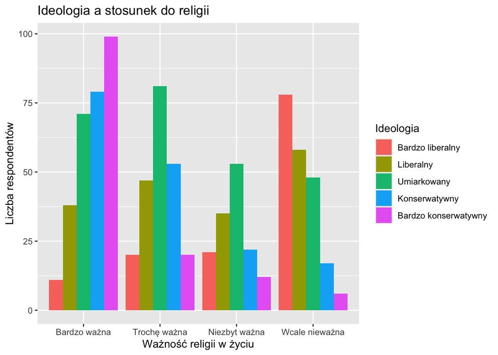

```r
####KOD
# Przekodowujemy ważność religii oraz ideologię, od razu zmieniając jej nazwę na "Ideologia"
cces_plot2 <- cces %>%
  filter(pew_religimp %in% 1:4, ideo5 %in% 1:5) %>%
  mutate(
    pew_religimp = factor(pew_religimp,
                          levels = 1:4,
                          labels = c("Bardzo ważna", "Trochę ważna",
                                     "Niezbyt ważna", "Wcale nieważna")),
    Ideologia = factor(ideo5,
                       levels = 1:5,
                       labels = c("Bardzo liberalny", "Liberalny", "Umiarkowany",
                                  "Konserwatywny", "Bardzo konserwatywny"))
  )

# Tworzymy wykres.
# position = "dodge" ustawia słupki obok siebie, a nie jedne na drugich,
# co jest standardem dla takich zestawień (choć zwykłe geom_bar() też zadziała).
ggplot(cces_plot2, aes(x = pew_religimp, fill = Ideologia)) +
  geom_bar(position = "dodge") +
  labs(
    x = "Ważność religii w życiu",
    y = "Liczba respondentów",
    title = "Ideologia a stosunek do religii"
  )
```

## Wykres 3

**Instrukcje:**

- W tej wizualizacji tworzysz własne dane do ćwiczeń.
- Utwórz tibble/ramkę danych z trzema kolumnami: Semestr, Student i Ocena.
- Powinno być sześć semestrów i trzech studentów (Amanda, Betty i Carol).
- Utwórz oceny dla studentów, używając polecenia `runif()`, z wartościami od 80 do 100.

**Wskazówka:** Będziesz potrzebować łącznie 18 ocen. * Wykres powinien wyglądać mniej więcej tak (Twoje wartości będą się nieznacznie różnić):

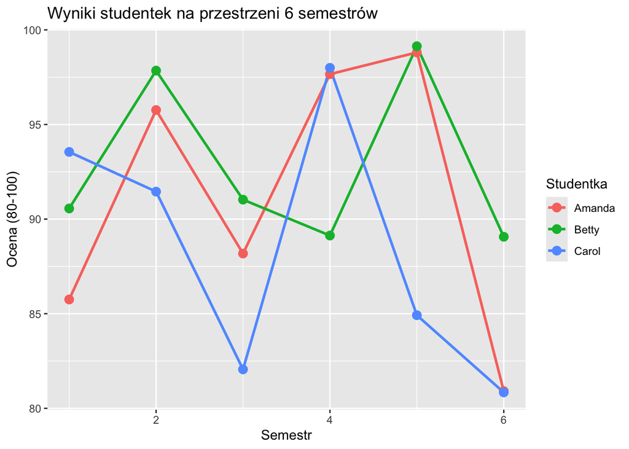

```r
####KOD
# Ustawiamy ziarno (seed), aby losowe oceny były takie same przy każdym uruchomieniu kodu
set.seed(123)

# Tworzymy ramkę danych
dane_oceny <- tibble(
  Semestr = rep(1:6, times = 3),
  Student = rep(c("Amanda", "Betty", "Carol"), each = 6),
  Ocena = runif(18, min = 80, max = 100)
)

# Tworzymy wykres liniowy
ggplot(dane_oceny, aes(x = Semestr, y = Ocena, color = Student)) +
  geom_line(size = 1) +
  geom_point(size = 3) +
  labs(
    x = "Semestr",
    y = "Ocena (80-100)",
    title = "Wyniki studentek na przestrzeni 6 semestrów",
    color = "Studentka"
  )
```